# Team 4 Interim Report Code Walkthrough

Tony Bodulovic, Jiayi Chai, Sarah Ligon, & Reba Yohannan  
NYU Wagner Research Capstone ’23 - ’24  
March 5, 2024

Project R scripts and data at github.com/ligonish/nyu-capstone-F23-S24.

*Last updated 2024-03-02, SL*

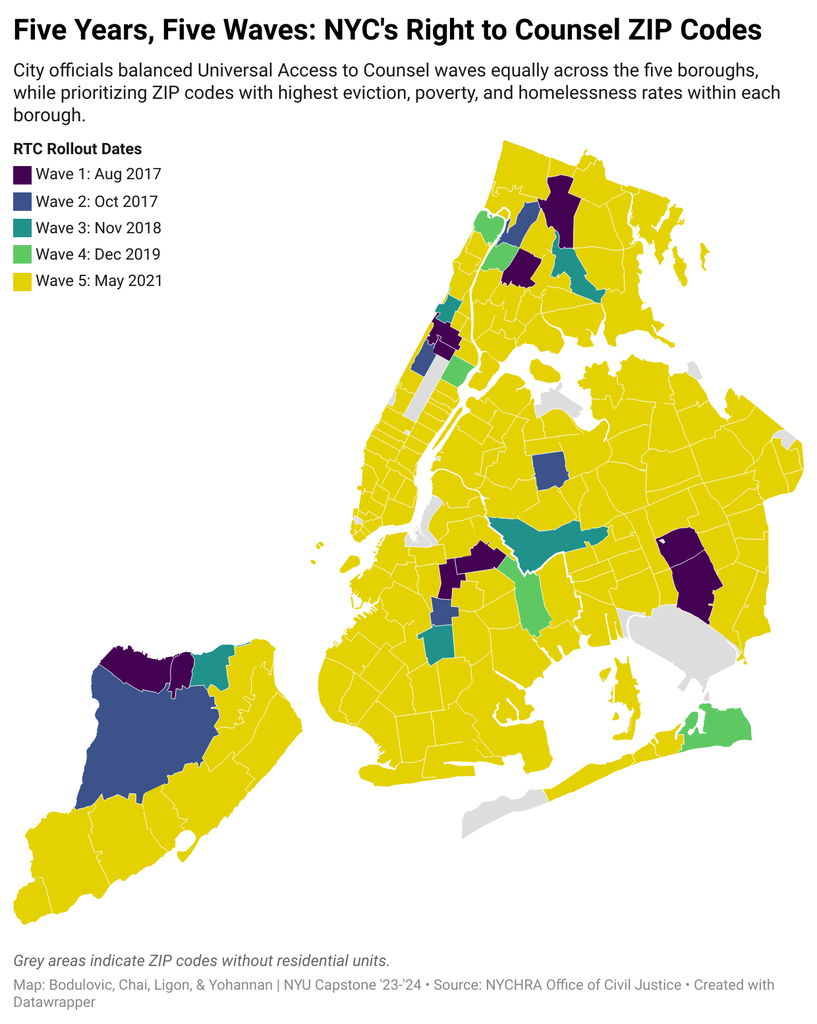

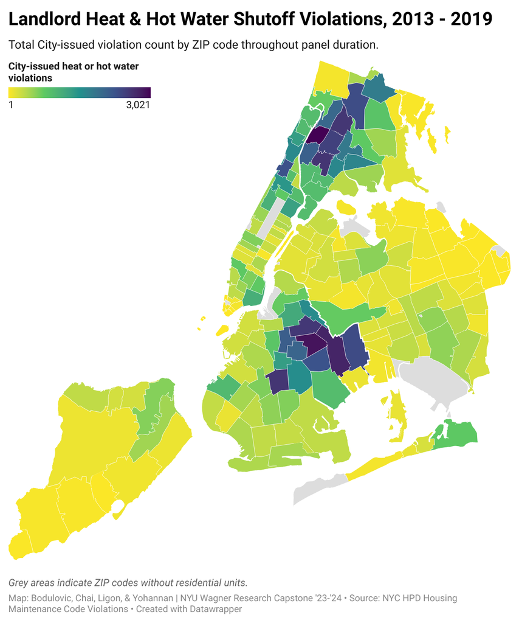

## Data Sources

- [NYC HPD Housing Maintenance Code Violations](https://data.cityofnewyork.us/Housing-Development/Housing-Maintenance-Code-Violations/wvxf-dwi5)
- [ACS 5-yr estimates, 2012-2021](https://walker-data.com/tidycensus/)
- [NYC DOHMH Zip Code Tabulation Areas](https://data.cityofnewyork.us/Health/Modified-Zip-Code-Tabulation-Areas-MODZCTA-/pri4-ifjk/data)
- [NYC Planning PLUTO Archive, 2012-2021](https://www.nyc.gov/site/planning/data-maps/open-data/bytes-archive.page)
- [NYC DOI Evictions Data](https://data.cityofnewyork.us/City-Government/Evictions/6z8x-wfk4/about_data)
- [JustFix NYC Rent Stabilized Unit Counts](https://www.justfix.org/en/tools)
- [Uniform Data System Mapper: ZIP to ZCTA Crosswalks](https://udsmapper.org/zip-code-to-zcta-crosswalk/)
- Callaway, Brantly and Pedro H.C. Sant’Anna. [“Difference-in-Differences with Multiple Time Periods”](https://doi.org/10.1016/j.jeconom.2020.12.001). *Journal of Econometrics*, Vol. 225, No. 2, pp. 200-230, 2021.
- Callaway, Brantly and Pedro Sant’Anna. [“Getting Started with the did Package”](https://bcallaway11.github.io/did/articles/did-basics.html). 08-29-2023

## R Libraries

```r
library(tidyverse)   # data cleaning & manipulation
library(tidycensus)  # allows direct download of ACS microdata
library(RSocrata)    # pulls from NYC OpenData API
library(janitor)     # data cleaning & easy table percentages
library(readxl)      # import Census.gov ZIP->ZCTA crosswalks from .xls format
library(priceR)      # CPI-adjust dollar amounts
library(lubridate)   # date variable normalization
library(zoo)         # stores evenly-counted year-month periods as numeric variables
library(did)         # Callaway & Sant'Anna's package implementing their staggered DiD method
library(viridis)     # plot color schemes
library(hrbrthemes)  # plot theming
library(kableExtra)  # prettier tables
library(vtable)      # summary stats in RMarkdown
```

## Data Collection

### NYC-HPD Housing & Maintenance Code Violations, 2013 - 2019

To use this method, you’ll need your own free app token to access NYC OpenData APIs. You can get one at data.cityofnewyork.us/profile/edit/developer_settings. Once you have it, store locally on your machine in place of the “XXXXXXXXX” value below.

```r
#token <- "XXXXXXXXXXXXXXXXXXXX"
```

Now visit https://nycopendata.socrata.com/Housing-Development/Housing-Maintenance-Code-Violations/wvxf-dwi5 and click the “API” tab. Choose “CSV” for API Endpoint and copy the resulting [URL](https://data.cityofnewyork.us/resource/wvxf-dwi5.csv).

HPD publishes a codebook detailing inspectors’ violation codes (see documentation/Housing_Maintenance_Code_Violations_User_Guide on our Github). We select the following subset of particularly severe heat and hot water shutoff violation categories as proxies for illegal eviction.

```r
v_codes <- c(577, 664, 666, 670, 742, 877, 964, 966, 970)

v_adm <- c("§27-2024", "§27-2028, 2032", "§27-2029", "§27-2031", "§27-2070", "§27-2024", "§27-2028, 2032", "§27-2029", "§27-2031")

v_desc <- c("PROVIDE ADEQUATE SUPPLY OF HOT WATER FOR THE FIXTURES", "PROVIDE AN ADEQUATE SUPPLY OF HEAT FROM AN APPROVED CENTRAL
 HEATING SYSTEM, OR AN APPROVED SYSTEM OF GAS OR ELECTRICAL HEATING IN GOOD OPERATING CONDITION FOR THE DWELLING UNIT", "PROVIDE AN ADEQUATE SUPPLY OF HEAT FOR THE APARTMENT", "PROVIDE HOT WATER AT ALL HOT WATER FIXTURES", "PROVIDE AN ADEQUATE SUPPLY OF GAS TO THE FIXTURES", "PROVIDE ADEQUATE SUPPLY OF HOT WATER FOR THE FIXTURES", "PROVIDE AN ADEQUATE SUPPLY OF HEAT FROM AN APPROVED CENTRAL
 HEATING SYSTEM, OR AN APPROVED SYSTEM OF GAS OR ELECTRICAL HEATING IN GOOD OPERATING CONDITION FOR THE DWELLING UNIT", "PROVIDE AN ADEQUATE SUPPLY OF HEAT FOR THE APARTMENT", "PROVIDE HOT WATER AT ALL HOT WATER FIXTURES")

tibble(v_codes, v_adm, v_desc) %>%
  kbl(col.names = c('Code', 'Law Violated ', 'HPD Description')) %>%
    kable_styling(full_width = F, html_font = "Roboto Condensed")
```

| Code | Law Violated | HPD Description |
| --- | --- | --- |
| 577 | §27-2024 | PROVIDE ADEQUATE SUPPLY OF HOT WATER FOR THE FIXTURES |
| 664 | §27-2028, 2032 | PROVIDE AN ADEQUATE SUPPLY OF HEAT FROM AN APPROVED CENTRAL HEATING SYSTEM, OR AN APPROVED SYSTEM OF GAS OR ELECTRICAL HEATING IN GOOD OPERATING CONDITION FOR THE DWELLING UNIT |
| 666 | §27-2029 | PROVIDE AN ADEQUATE SUPPLY OF HEAT FOR THE APARTMENT |
| 670 | §27-2031 | PROVIDE HOT WATER AT ALL HOT WATER FIXTURES |
| 742 | §27-2070 | PROVIDE AN ADEQUATE SUPPLY OF GAS TO THE FIXTURES |
| 877 | §27-2024 | PROVIDE ADEQUATE SUPPLY OF HOT WATER FOR THE FIXTURES |
| 964 | §27-2028, 2032 | PROVIDE AN ADEQUATE SUPPLY OF HEAT FROM AN APPROVED CENTRAL HEATING SYSTEM, OR AN APPROVED SYSTEM OF GAS OR ELECTRICAL HEATING IN GOOD OPERATING CONDITION FOR THE DWELLING UNIT |
| 966 | §27-2029 | PROVIDE AN ADEQUATE SUPPLY OF HEAT FOR THE APARTMENT |
| 970 | §27-2031 | PROVIDE HOT WATER AT ALL HOT WATER FIXTURES |

```r
rm(v_adm, v_codes, v_desc)
```

Requesting these directly from NYC OpenData’s API, with date range beginning in 2013 (the first complete year of digitized HPD reports) and ending before the passage of HSTPA in June 2019:

```r
url <- "https://data.cityofnewyork.us/resource/wvxf-dwi5.json?$where= inspectiondate >= '2013-01-01T00:00:00.000' and inspectiondate <= '2019-05-31T00:00:00.000' and (ordernumber = '577' or ordernumber = '664' or ordernumber = '666' or ordernumber = '670' or ordernumber = '742' or ordernumber = '877' or ordernumber = '964' or ordernumber = '966' or ordernumber = '970')"

violations <- read.socrata(url = url, app_token = token)

rm(token, url)
```

*10,4050 obs. of 41 variables*

### U.S. Census: ZIP-Level ACS 5-Year Estimates

Start by getting a U.S. Census API key and storing it on your local system. Here’s a [general tutorial](https://walker-data.com/tidycensus/articles/spatial-data.html); a [NYC-specific, tidyverse-friendly guide](https://justinmorganwilliams.medium.com/import-nyc-census-data-into-r-with-tidycensus-c94d2d1f23fa); and a great writeup on pulling [multiple years at once](https://mattherman.info/blog/tidycensus-mult-year/) using purrr loops (method replicated below).

```r
v17 <- load_variables(2017, "acs5")
```

We select a range of potential covariates from the renter-occupied housing universe:

```r
census_variables <- c("B25001_001",   # Total housing units (added 2-18-2024, SL)
                      "B25002_003",   # Total vacant housing units (added 2-18-2024, SL)
                      "B25032_001",   # Total occupied housing units (added 2-8-2024, SL: for pct_rent estimation)
                      "B25032_013",   # Total renter-occupied housing units
                      "B25008_003",   # Total population in renter-occupied housing units
                      "B25119_003",   # Median household income (renter-occupied)
                      "B25037_003",   # Median year structure built (renter-occupied)
                      "B25039_003",   # Median year householder moved into unit (renter-occupied)
                      "B25064_001",   # Median gross rent (dollars)
                      "B25071_001",   # Median gross rent as percentage of household income in past 12 months (i.e. rent burden)
                      "B25013_011",   # Total renter-occupied housing units where householder has bachelors' degree or higher
                      "B25003H_003",  # Total rent-occ units where householder is white alone, not Hispanic or Latino
                      "B25003B_003",  # Total rent-occ units where householder is Black alone
                      "B25003D_003",  # Total rent-occ units where householder is Asian alone
                      "B25003I_003",  # Total rent-occ units where householder is Hispanic or Latino
                      "B17017_001",   # Total households
                      "B17017_002"    # Total households w/ income below poverty threshold in past yr
                      )

rm(v17)
```

And the years in our date range of interest:

```r
years <- lst(2013, 2014, 2015, 2016, 2017, 2018, 2019)
```

Obtaining seven years’ worth of ZIP-level ACS estimates.

```r
acs5_zctas <- map_dfr(
  years,
  ~ get_acs(
    geography = "zcta",
    variables = census_variables,
    year = .x,
    survey = "acs5",
    output = "wide",
    geometry = FALSE),   # can add these later for mapping
  .id = "year") %>%
  select(-NAME, -ends_with("M")) %>%
  mutate(year = as.numeric(year))%>%
  arrange(GEOID, year)

rm(years, census_variables)
```

*231,840 obs. of 19 vars* After trimming these to only include ZIP codes within New York City, using a c. 2010 ZIP/ZCTA list downloaded from NYC OpenData:

```r
zctas <- read_csv("data_build/2010_nyc_zctas.csv") %>%
  mutate(GEOID = as.character(ZCTA))
```

*216 obs. of 2 vars* We rename the variables more legibly and generate our covariates of interest as rates within each ZIP boundary for easier comparability across ZIPs.

```r
acs5_zctas <- acs5_zctas %>%
  semi_join(zctas, by = "GEOID") %>%
  rename(tot_units = B25001_001E,
         tot_occ_units = B25032_001E,
         tot_vac_units = B25002_003E,
         renter_occ_units = B25032_013E,
         tot_hh = B17017_001E,
         tot_hh_pov = B17017_002E,
         tot_pop_rou = B25008_003E,
         med_hh_inc_rou = B25119_003E,
         med_yr_blt_rou = B25037_003E,
         med_yr_moved_in_rou = B25039_003E,
         med_gross_rent = B25064_001E,
         med_rent_burden = B25071_001E,
         tot_college_degree_rou = B25013_011E,
         tot_wh_rou = B25003H_003E,
         tot_bl_rou = B25003B_003E,
         tot_asn_rou = B25003D_003E,
         tot_ltx_rou = B25003I_003E
         ) %>%
  mutate(med_gross_rent_2020_adj = adjust_for_inflation(med_gross_rent, year, "US", to_date = 2020),
         med_gross_rent_2020_adj = round_to_nearest(med_gross_rent_2020_adj, 1), .after = med_gross_rent) %>%
  mutate(med_hh_inc_rou_2020_adj = adjust_for_inflation(med_hh_inc_rou, year, "US", to_date = 2020),
         med_hh_inc_rou_2020_adj = round_to_nearest(med_hh_inc_rou_2020_adj, 1), .after = med_hh_inc_rou) %>%
  mutate(pct_college_deg_rou = round(tot_college_degree_rou/renter_occ_units, 2), .after = tot_college_degree_rou) %>%
  mutate(pct_wh_rou = round(tot_wh_rou/renter_occ_units, 2), .after = tot_wh_rou) %>%
  mutate(pct_bl_rou = round(tot_bl_rou/renter_occ_units, 2), .after = tot_bl_rou) %>%
  mutate(pct_asn_rou = round(tot_asn_rou/renter_occ_units, 2), .after = tot_asn_rou) %>%
  mutate(pct_ltx_rou = round(tot_ltx_rou/renter_occ_units, 2), .after = tot_ltx_rou) %>%
  mutate(pct_rent = round(renter_occ_units/tot_occ_units, 2), .after = renter_occ_units) %>%
  mutate(pct_vac = round(tot_vac_units/tot_occ_units, 2), .after = tot_vac_units) %>%
  mutate(pct_pov = round(tot_hh_pov/tot_hh, 2), .after = tot_hh_pov) %>%
  fill(med_hh_inc_rou, med_hh_inc_rou_2020_adj, med_yr_moved_in_rou) # impute from prev yr the missing values for 2015 household income & median year moved in ZIP 10006, and 2016 hh inc for ZIP 10464
```

```
## Generating URL to request all 296 results
## Retrieving inflation data for US
## Generating URL to request all 63 results
## Generating URL to request all 296 results
## Retrieving inflation data for US
## Generating URL to request all 63 results
```

```r
rm(zctas)
```

*1498 obs of 29 vars*

### NYC-DOI Eviction Counts

```r
evict <- read_csv("data_raw/jan_to_aug_evictions_2017.csv") %>% # 2017 baseline Jan-Aug eviction counts, by DOI and collated in NYC OpenData
  clean_names %>%
  mutate(zip = as.numeric(eviction_postcode), .keep = "unused") %>%
  rename(evicts_17 = count)
```

*183 obs of 2 vars*

### NYC-JustFix Rent Stabilization Counts

```r
rs <- read_csv("data_build/rs_17_full.csv") %>%   # baseline 2017 rent-stabilized unit counts, via Furman + Tony
  mutate(zip = as.numeric(zipcode), .keep = "unused") %>%
  rename(rs_17 = rs_17_count)
```

*175 obs ov 2 vars*

### RTC treatment dates & indicators

```r
rtc_zips <- read_csv("data_build/rtc_zip_rollout.csv") %>% # Source: Ellen et al (2021), "Early Evidence on Eviction Patterns", pg.8 footnotes
  clean_names() %>%
  mutate(zip = as.numeric(zip)) %>%
  rename(rtc_treat_date = date_added) %>%
  select(cohort, rtc_treat_date, zip) %>%
  filter(cohort != 5)
```

## Data Cleaning

```r
violations <- violations %>%
  remove_constant() %>%
  select(violationid,
         buildingid,
         boroid,
         boro,
         housenumber,
         lowhousenumber,
         highhousenumber,
         streetname,
         zip,
         apartment,
         story,
         block,
         lot,
         class,
         inspectiondate,
         ordernumber,
         novdescription,
         novtype,
         rentimpairing,
         latitude,
         longitude,
         censustract,
         bin,
         bbl,
         nta) %>%
  mutate(inspectiondate = date(inspectiondate),  # baseline date for each observation; earlier date would require using complaints database instead/as well
         inspection_yr = year(inspectiondate),  # for manipulation/visualization/interactions
         inspection_mo = month(inspectiondate), # allows analysis of seasonal trends and overall more detailed time-constant fixed effects (esp important in staggered DiD)
         inspection_yr_mo = as.yearmon(inspectiondate),
         zip = as.integer(zip),
         violationid = as.integer(violationid))
```

*104,050 obs of 28 vars*

Fix missing or mis-entered ZIPs

```r
corrected_zips <- read.csv("data_build/corrected_zips_2012_2020.csv") %>%  # hand corrected by Jiayi/Reba
  mutate(inspectiondate = date(inspectiondate),  # keeps date syntax compatible with rest of data after merge
         inspection_yr = year(inspectiondate),
         inspection_mo = month(inspectiondate),
         inspection_yr_mo = as.yearmon(inspectiondate))

violations <- violations %>%
  filter(zip != "2016",   # two ZIPs mis-entered as "2016"
         !is.na(zip)) %>%
  bind_rows(corrected_zips) %>%   # updated from rbind.fill to dplyr syntax so rest of code runs in tidyverse
  mutate(zip = case_when( # correcting a few further misentered ZIPs discovered during later analysis
    zip == 10129 ~ 10128, # violation ID 11725954 entered with ZIP typo
    zip == 10435 ~ 11435, # violation ID 10549312 entered with ZIP typo
    zip == 11452 ~ 10452, # violation IDs 10599781 & 10599866 entered with ZIP typos
    zip == 11249 ~ 11211, # c. 2010 ZIP 11249 corresponds to c. 2010 ZCTA 11211, both adjacent in Williamsburg; all other ZIPS/ZCTAs mergeable
    TRUE ~ zip
  ))
```

*104,063 obs of 28 vars*

Collapse to get monthly violation totals at ZIP code level

```r
violations <- violations %>%
  group_by(zip, inspection_yr_mo) %>%
  summarize(n_violations = n_distinct(violationid, na.rm = F)) %>%     # 17,640 obs from Jan 2012 - Feb 2020
  ungroup() %>%
  complete(zip, inspection_yr_mo, fill = list(n_violations = 0)) # expand all 12 annual yearmonth observations for all zip codes, even if no violations reported
```

*14,608 obs of 3 vars*

Merge/generate census, eviction, & rent stabilization covariates

```r
acs5_zctas <- acs5_zctas %>%
  rename(zip = GEOID) %>%
  mutate(zip = as.integer(zip))
```

```r
violations <- violations %>%
  mutate(year = year(inspection_yr_mo)) %>%
  group_by(zip, inspection_yr_mo) %>%
  left_join(acs5_zctas, by = c("year", "zip")) %>%   # Census covariates
  left_join(evict, by = "zip") %>%    # eviction covariate
  left_join(rs, by = "zip") %>%   # rent stabilization covariate
  mutate(n_violations_per_1k_units = ((n_violations/renter_occ_units)*1000), .after = n_violations) %>%
  ungroup() %>%
  group_by(zip) %>%
  mutate(across(everything(), ~replace(.x, is.nan(.x), 0))) %>% # correcting generated percentages with "0" numerators that were showing up as NaN values
  mutate(
    evict_rate_17 = case_when(
      year == 2017 ~ (evicts_17/renter_occ_units)),   # time-invariant baseline version of eviction rate from treatment selection year, for CS-DiD
    rs_rate_17 = case_when(
      year == 2017 ~ (rs_17/renter_occ_units)),   # time-invariant rent stabilization rate
    pct_pov_17 = case_when(
      year == 2017 ~ pct_pov),   # time-invariant poverty rate
    pct_wh_17 = case_when(
      year == 2017 ~ pct_wh_rou)   # time-invariant control for baseline POC residents at treatment selection year
  ) %>%
  fill(evict_rate_17, rs_rate_17, pct_pov_17, pct_wh_17, .direction = "updown") %>%
  select(-year) %>%
  ungroup()
```

*14,608 obs of 37 vars*

Generate RTC treatment status dates & indicators

```r
violations <- violations %>%
  group_by(zip, inspection_yr_mo) %>%
  left_join(rtc_zips, by = "zip") %>%
  mutate(
    cohort = replace_na(cohort, 5),
    rtc_treat_date = replace_na(rtc_treat_date, as_date("2021-05-11")), # all ZIPS not in cohorts 1-4 were added to treatment May 2021
    treat_yr_mo = as.yearmon(rtc_treat_date),
    treated = case_when(
      treat_yr_mo > inspection_yr_mo ~ 0,
      TRUE ~ 1)) %>%
  ungroup
```

Select pre-HSTPA time period

```r
violations <- violations %>%
  filter(inspection_yr_mo >= "Jan 2013" & inspection_yr_mo <= "May 2019") %>%
  mutate(zip = as.character(zip))

rm(corrected_zips, evict, rs, rtc_zips)
```

*13,552 observations of 41 variables.*

## Summary Statistics

Number of Months Treated

```r
violations %>%
  group_by(cohort, treated) %>%
  summarize(n_months_treated = n_distinct(inspection_yr_mo),
            n_zip_codes = n_distinct(zip)) %>%
  pivot_wider(names_from = treated, values_from = n_months_treated) %>%
  mutate(rtc_date = case_when(
    cohort == 1 ~ "Aug. 2017",
    cohort == 2 ~ "Oct. 2017",
    cohort == 3 ~ "Nov. 2018",
    cohort == 4 ~ "Dec. 2019",
    cohort == 5 ~ "May 2021"),
    .after = cohort) %>%
  replace(is.na(.), 0) %>%
  adorn_totals(,,,, n_zip_codes) %>%
  kable(
    caption = 'NYC Right-to-Counsel Treatment Waves Observed in 2013 - 2019 Study Period',
    col.names = c('Wave', 'RTC Treatment Date', 'ZIPs Treated', 'Months Observed Pre-Treatment', 'Months Observed Post-Treatment')) %>%
    kable_styling(full_width = F, html_font = "Roboto Condensed")
```

NYC Right-to-Counsel Treatment Waves Observed in 2013 - 2019 Study Period

Wave

RTC Treatment Date

ZIPs Treated

Months Observed Pre-Treatment

Months Observed Post-Treatment

1

Aug. 2017

10

55

22

2

Oct. 2017

5

57

20

3

Nov. 2018

5

70

7

4

Dec. 2019

5

77

0

5

May 2021

151

77

0

Total

176

Table 1

```r
violations %>%
  ungroup() %>%
  mutate(cohort = factor(cohort),
         treated = factor(treated)) %>%
  st(group = 'cohort',
     group.test = T,
     col.align = 'center',
     title = 'Table 1. Summary Statistics by RTC Treatment Cohort: NYC Renter-Occupied Units, January 2012 - May 2019',
     out = 'kable') %>%
  kable_styling(full_width = F, html_font = "Roboto Condensed")
```

| cohort Variable | 1 N | 1 Mean | 1 SD | 2 N | 2 Mean | 2 SD | 3 N | 3 Mean | 3 SD | 4 N | 4 Mean | 4 SD | 5 N | 5 Mean | 5 SD | Test |
| --- | --- | --- | --- | --- | --- | --- | --- | --- | --- | --- | --- | --- | --- | --- | --- | --- |
| n_violations | 770 | 17 | 18 | 385 | 13 | 13 | 385 | 17 | 18 | 385 | 23 | 21 | 11627 | 6.1 | 10 | F=435.256*** |
| n_violations_per_1k_units | 770 | 1.1 | 0.91 | 385 | 0.57 | 0.56 | 385 | 0.87 | 0.79 | 385 | 1 | 0.81 | 11627 | 0.49 | 0.74 | F=194.406*** |
| tot_units | 770 | 21616 | 9871 | 385 | 33317 | 8195 | 385 | 28331 | 11136 | 385 | 27059 | 7205 | 11627 | 18425 | 9867 | F=370.857*** |
| tot_vac_units | 770 | 2018 | 1092 | 385 | 2638 | 1508 | 385 | 2253 | 950 | 385 | 2090 | 1023 | 11627 | 1690 | 1433 | F=69.257*** |
| pct_vac | 770 | 0.11 | 0.034 | 385 | 0.082 | 0.03 | 385 | 0.091 | 0.022 | 385 | 0.08 | 0.027 | 11627 | 0.1 | 0.065 | F=31.003*** |
| tot_occ_units | 770 | 19598 | 9117 | 385 | 30680 | 6882 | 385 | 26078 | 10296 | 385 | 24969 | 6345 | 11627 | 16735 | 8918 | F=400.599*** |
| renter_occ_units | 770 | 14987 | 9083 | 385 | 21036 | 7684 | 385 | 20198 | 9421 | 385 | 21560 | 5872 | 11627 | 10915 | 7443 | F=492.553*** |
| pct_rent | 770 | 0.7 | 0.19 | 385 | 0.7 | 0.23 | 385 | 0.72 | 0.18 | 385 | 0.86 | 0.09 | 11627 | 0.62 | 0.22 | F=164.447*** |
| tot_pop_rou | 770 | 39543 | 24408 | 385 | 54092 | 18831 | 385 | 54788 | 25519 | 385 | 58936 | 14694 | 11627 | 27267 | 20280 | F=555.95*** |
| med_hh_inc_rou | 770 | 34746 | 8771 | 385 | 45378 | 9271 | 385 | 40995 | 9961 | 385 | 31217 | 7456 | 11627 | 56849 | 31854 | F=190.855*** |
| med_hh_inc_rou_2020_adj | 770 | 37187 | 9030 | 385 | 48600 | 9609 | 385 | 43851 | 10113 | 385 | 33415 | 7642 | 11627 | 60864 | 33863 | F=193.934*** |
| med_yr_blt_rou | 770 | 1835 | 463 | 385 | 1692 | 662 | 385 | 1686 | 660 | 385 | 1841 | 454 | 11627 | 1850 | 439 | F=22.472*** |
| med_yr_moved_in_rou | 770 | 2007 | 2.8 | 385 | 2007 | 2.8 | 385 | 2007 | 2.8 | 385 | 2006 | 2.6 | 11627 | 2008 | 3.1 | F=62.447*** |
| med_gross_rent | 770 | 1129 | 119 | 385 | 1317 | 128 | 385 | 1237 | 114 | 385 | 1072 | 120 | 11627 | 1499 | 481 | F=232.363*** |
| med_gross_rent_2020_adj | 770 | 1209 | 108 | 385 | 1411 | 122 | 385 | 1324 | 97 | 385 | 1149 | 116 | 11627 | 1605 | 505 | F=242.233*** |
| med_rent_burden | 770 | 35 | 4.9 | 385 | 34 | 4.2 | 385 | 34 | 3.1 | 385 | 34 | 4 | 11627 | 32 | 4.9 | F=117.322*** |
| tot_college_degree_rou | 770 | 3870 | 2897 | 385 | 7674 | 6567 | 385 | 5319 | 2610 | 385 | 4477 | 2114 | 11627 | 4185 | 3996 | F=80.908*** |
| pct_college_deg_rou | 770 | 0.24 | 0.12 | 385 | 0.32 | 0.17 | 385 | 0.25 | 0.052 | 385 | 0.22 | 0.087 | 11627 | 0.39 | 0.23 | F=181.972*** |
| tot_wh_rou | 770 | 1934 | 1747 | 385 | 5677 | 5793 | 385 | 4423 | 3685 | 385 | 2377 | 1608 | 11627 | 4102 | 4452 | F=74.911*** |
| pct_wh_rou | 770 | 0.13 | 0.094 | 385 | 0.29 | 0.23 | 385 | 0.24 | 0.14 | 385 | 0.13 | 0.092 | 11627 | 0.4 | 0.27 | F=315.888*** |
| tot_bl_rou | 770 | 7635 | 3988 | 385 | 5135 | 4769 | 385 | 7783 | 8145 | 385 | 8569 | 4612 | 11627 | 2392 | 3692 | F=686.923*** |
| pct_bl_rou | 770 | 0.53 | 0.18 | 385 | 0.24 | 0.24 | 385 | 0.35 | 0.22 | 385 | 0.38 | 0.19 | 11627 | 0.21 | 0.25 | F=361.998*** |
| tot_asn_rou | 770 | 558 | 478 | 385 | 2873 | 3262 | 385 | 846 | 511 | 385 | 757 | 880 | 11627 | 1265 | 1820 | F=120.913*** |
| pct_asn_rou | 770 | 0.037 | 0.022 | 385 | 0.14 | 0.14 | 385 | 0.042 | 0.016 | 385 | 0.032 | 0.028 | 11627 | 0.13 | 0.12 | F=208.938*** |
| tot_ltx_rou | 770 | 5169 | 5396 | 385 | 7576 | 5620 | 385 | 7371 | 3765 | 385 | 10391 | 4447 | 11627 | 3150 | 3726 | F=541.128*** |
| pct_ltx_rou | 770 | 0.31 | 0.17 | 385 | 0.34 | 0.22 | 385 | 0.38 | 0.12 | 385 | 0.48 | 0.15 | 11627 | 0.26 | 0.19 | F=187.661*** |
| tot_hh | 770 | 19598 | 9117 | 385 | 30680 | 6882 | 385 | 26078 | 10296 | 385 | 24969 | 6345 | 11627 | 16735 | 8918 | F=400.599*** |
| tot_hh_pov | 770 | 5002 | 3112 | 385 | 5583 | 1765 | 385 | 4931 | 1851 | 385 | 7917 | 2988 | 11627 | 2972 | 2635 | F=528.086*** |
| pct_pov | 770 | 0.25 | 0.071 | 385 | 0.19 | 0.071 | 385 | 0.19 | 0.038 | 385 | 0.31 | 0.064 | 11627 | 0.16 | 0.097 | F=368.987*** |
| evicts_17 | 770 | 147 | 116 | 385 | 142 | 100 | 385 | 164 | 99 | 385 | 188 | 90 | 11550 | 65 | 68 | F=669.104*** |
| rs_17 | 770 | 6301 | 6335 | 385 | 11290 | 6086 | 385 | 10418 | 7683 | 385 | 9191 | 4721 | 11319 | 4356 | 4007 | F=503.961*** |
| evict_rate_17 | 770 | 0.01 | 0.0045 | 385 | 0.007 | 0.0039 | 385 | 0.0086 | 0.0026 | 385 | 0.0086 | 0.0032 | 11550 | 0.0064 | 0.0043 | F=209.973*** |
| rs_rate_17 | 770 | 0.31 | 0.21 | 385 | 0.49 | 0.25 | 385 | 0.43 | 0.22 | 385 | 0.44 | 0.22 | 11319 | 0.34 | 0.21 | F=89.563*** |
| pct_pov_17 | 770 | 0.24 | 0.073 | 385 | 0.19 | 0.07 | 385 | 0.19 | 0.035 | 385 | 0.31 | 0.067 | 11627 | 0.16 | 0.096 | F=379.632*** |
| pct_wh_17 | 770 | 0.14 | 0.098 | 385 | 0.29 | 0.22 | 385 | 0.25 | 0.13 | 385 | 0.13 | 0.097 | 11627 | 0.39 | 0.27 | F=284.392*** |
| treated | 770 |  |  | 385 |  |  | 385 |  |  | 385 |  |  | 11627 |  |  | X2=3242.502*** |
| … 0 | 550 | 71% |  | 285 | 74% |  | 350 | 91% |  | 385 | 100% |  | 11627 | 100% |  |  |
| … 1 | 220 | 29% |  | 100 | 26% |  | 35 | 9% |  | 0 | 0% |  | 0 | 0% |  |  |

Statistical significance markers: * p<0.1; ** p<0.05; *** p<0.01

Key Covariate Summaries, by Cohort (to highlight heterogeneity)

```r
violations %>%
  group_by(cohort) %>%
  summarize(
    #violations = sum(n_violations),
            violation_rate = mean(n_violations_per_1k_units, na.rm = TRUE),
            evict_rate = mean(evict_rate_17, na.rm = TRUE),
            rs_rate = mean(rs_rate_17, na.rm = TRUE),
            pct_pov = mean(pct_pov_17, na.rm = TRUE),
            hh_inc = mean(med_hh_inc_rou_2020_adj, na.rm = TRUE),
            rent_burden = mean(med_rent_burden, na.rm = TRUE),
            pct_college_grads = mean(pct_college_deg_rou, na.rm = TRUE),
            pct_wh = mean(pct_wh_rou, na.rm = TRUE),
            pct_bl = mean(pct_bl_rou, na.rm = TRUE),
            pct_asn = mean(pct_asn_rou, na.rm = TRUE),
            pct_ltx = mean(pct_ltx_rou, na.rm = TRUE)
            ) %>%
  knitr::kable(digits = 2,
               caption = 'Selected Potential Covariates by RTC Treatment Cohort: NYC Renter-Occupied Units, January 2012 - May 2019',
               col.names = c("Treatment Cohort", "Violation Rate", "2017 Eviction Rate", "2017 Rent Stabilization Rate", "2017 Poverty Rate", "Median HH Income in 2020 USD", "Rent Burden", "Percent College Graduates", "Percent White", "Percent Black", "Percent Asian", "Percent Latinx")) %>%
  kable_styling(full_width = F, html_font = "Roboto Condensed")
```

| Treatment Cohort | Violation Rate | 2017 Eviction Rate | 2017 Rent Stabilization Rate | 2017 Poverty Rate | Median HH Income in 2020 USD | Rent Burden | Percent College Graduates | Percent White | Percent Black | Percent Asian | Percent Latinx |
| --- | --- | --- | --- | --- | --- | --- | --- | --- | --- | --- | --- |
| 1 | 1.14 | 0.01 | 0.31 | 0.24 | 37187.16 | 34.63 | 0.24 | 0.13 | 0.53 | 0.04 | 0.31 |
| 2 | 0.57 | 0.01 | 0.49 | 0.19 | 48599.68 | 33.87 | 0.32 | 0.29 | 0.24 | 0.14 | 0.34 |
| 3 | 0.87 | 0.01 | 0.43 | 0.19 | 43851.36 | 33.64 | 0.25 | 0.24 | 0.35 | 0.04 | 0.38 |
| 4 | 1.02 | 0.01 | 0.44 | 0.31 | 33415.12 | 33.95 | 0.22 | 0.13 | 0.38 | 0.03 | 0.48 |
| 5 | 0.49 | 0.01 | 0.34 | 0.16 | 60863.55 | 31.62 | 0.39 | 0.40 | 0.21 | 0.13 | 0.26 |

Try graphing these?

```r
for_maps <- violations %>%
  group_by(cohort, zip) %>%
  summarize(violations = sum(n_violations),
            violation_rate = mean(n_violations_per_1k_units, na.rm = TRUE),
            evict_rate = mean(evict_rate_17, na.rm = TRUE),
            rs_rate = mean(rs_rate_17, na.rm = TRUE),
            pct_pov = mean(pct_pov_17, na.rm = TRUE),
            hh_inc = mean(med_hh_inc_rou_2020_adj, na.rm = TRUE),
            rent_burden = mean(med_rent_burden, na.rm = TRUE),
            pct_college_grads = mean(pct_college_deg_rou, na.rm = TRUE),
            pct_wh = mean(pct_wh_rou, na.rm = TRUE),
            pct_bl = mean(pct_bl_rou, na.rm = TRUE),
            pct_asn = mean(pct_asn_rou, na.rm = TRUE),
            pct_ltx = mean(pct_ltx_rou, na.rm = TRUE)
            )

write_csv(for_maps, "data_build/for_maps.csv")

rm(for_maps)
```

## Data Analysis

### CS-DiD: No Covariates

Callaway & Sant’Anna’s package requires time and treatment periods to be stored as numeric variables, and never-treated groups should be assigned treatment period “0”.

```r
violations_13_19 <- violations %>%
  mutate(inspection_yr_mo_num = round(as.numeric(inspection_yr_mo), digits = 2), .after = inspection_yr_mo) %>%
  mutate(treat_yr_mo_num = round(as.numeric(treat_yr_mo),digits = 2), .after = treat_yr_mo) %>%
  mutate(
    zip = as.numeric(zip),
    treat_yr_mo_zero = case_when(
      treat_yr_mo == "May 2021" ~ as.numeric(0),
      treat_yr_mo == "Dec 2019" ~ as.numeric(0),
      TRUE ~ treat_yr_mo_num
  ))
```

*13,552 observations of 44 variables*

#### Group-Time Average Treatment Effects (ATE), No Covariates

```r
est_test <- att_gt(yname = "n_violations_per_1k_units",
                   gname = "treat_yr_mo_zero",      # year-month first treated
                   idname = "zip",
                   tname = "inspection_yr_mo_num",  # year-month time periods
                   xformla = ~1,
                   data = violations_13_19,
                   allow_unbalanced_panel = TRUE,   # prevents model from forcibly balancing panel by dropping observations
                   control_group = "notyettreated", # controls are both not-yet-treated within 2013-2019 (Cohorts 2 & 3) and never-treated until after 2019 (Cohorts 4 & 5)
                   est_method = "dr")   # doubly-robust standard errors
summary(est_test)
```

```
##
## Call:
## att_gt(yname = "n_violations_per_1k_units", tname = "inspection_yr_mo_num",
##     idname = "zip", gname = "treat_yr_mo_zero", xformla = ~1,
##     data = violations_13_19, allow_unbalanced_panel = TRUE, control_group = "notyettreated",
##     est_method = "dr")
##
## Reference: Callaway, Brantly and Pedro H.C. Sant'Anna.  "Difference-in-Differences with Multiple Time Periods." Journal of Econometrics, Vol. 225, No. 2, pp. 200-230, 2021. <https://doi.org/10.1016/j.jeconom.2020.12.001>, <https://arxiv.org/abs/1803.09015>
##
## Group-Time Average Treatment Effects:
##    Group    Time ATT(g,t) Std. Error [95% Simult.  Conf. Band]
##  2017.58 2013.08  -0.6673     0.2527       -1.3770      0.0424
##  2017.58 2013.17  -0.3229     0.2047       -0.8980      0.2521
##  2017.58 2013.25  -0.0151     0.1876       -0.5421      0.5118
##  2017.58 2013.33  -0.1331     0.1228       -0.4782      0.2119
##  2017.58 2013.42  -0.2493     0.1690       -0.7239      0.2253
##  2017.58 2013.50   0.0557     0.1615       -0.3980      0.5094
##  2017.58 2013.58  -0.0402     0.1192       -0.3749      0.2945
##  2017.58 2013.67   0.1376     0.1084       -0.1668      0.4420
##  2017.58 2013.75  -0.0020     0.1621       -0.4574      0.4534
##  2017.58 2013.83   0.4868     0.3717       -0.5573      1.5309
##  2017.58 2013.92   0.4795     0.4047       -0.6571      1.6162
##  2017.58 2014.00   0.9206     0.2652        0.1756      1.6656 *
##  2017.58 2014.08  -1.3852     0.3170       -2.2757     -0.4947 *
##  2017.58 2014.17   0.0032     0.1793       -0.5004      0.5069
##  2017.58 2014.25  -0.2728     0.2446       -0.9598      0.4141
##  2017.58 2014.33  -0.1037     0.1831       -0.6179      0.4105
##  2017.58 2014.42   0.0934     0.2163       -0.5142      0.7010
##  2017.58 2014.50  -0.1380     0.1023       -0.4253      0.1492
##  2017.58 2014.58   0.0257     0.1836       -0.4900      0.5414
##  2017.58 2014.67   0.0265     0.0993       -0.2525      0.3056
##  2017.58 2014.75  -0.0611     0.1164       -0.3881      0.2658
##  2017.58 2014.83   0.4479     0.3282       -0.4741      1.3698
##  2017.58 2014.92   0.0151     0.3663       -1.0137      1.0440
##  2017.58 2015.00   0.3248     0.2211       -0.2962      0.9457
##  2017.58 2015.08   0.1015     0.2460       -0.5895      0.7925
##  2017.58 2015.17  -0.2315     0.2711       -0.9929      0.5299
##  2017.58 2015.25  -0.8305     0.3040       -1.6844      0.0234
##  2017.58 2015.33  -0.0440     0.1019       -0.3303      0.2424
##  2017.58 2015.42   0.0911     0.1214       -0.2499      0.4322
```

[output cut: 189 more lines]

```
##  2018.83 2018.58   0.3356     0.2511       -0.3696      1.0408
##  2018.83 2018.67  -0.1839     0.3638       -1.2059      0.8381
##  2018.83 2018.75   0.3395     0.1728       -0.1459      0.8249
##  2018.83 2018.83  -0.1873     0.1664       -0.6547      0.2801
##  2018.83 2018.92   0.3383     0.3902       -0.7576      1.4343
##  2018.83 2019.00   0.5547     0.4244       -0.6374      1.7467
##  2018.83 2019.08  -0.0982     0.4633       -1.3995      1.2031
##  2018.83 2019.17  -0.2349     0.2522       -0.9434      0.4735
##  2018.83 2019.25   0.0830     0.1286       -0.2783      0.4444
##  2018.83 2019.33  -0.5300     0.2145       -1.1325      0.0725
## ---
## Signif. codes: `*' confidence band does not cover 0
##
## Control Group:  Not Yet Treated,  Anticipation Periods:  0
## Estimation Method:  Doubly Robust
```

*228 rows*

Plotting results for parallel pre-trends check (again, no covariates)

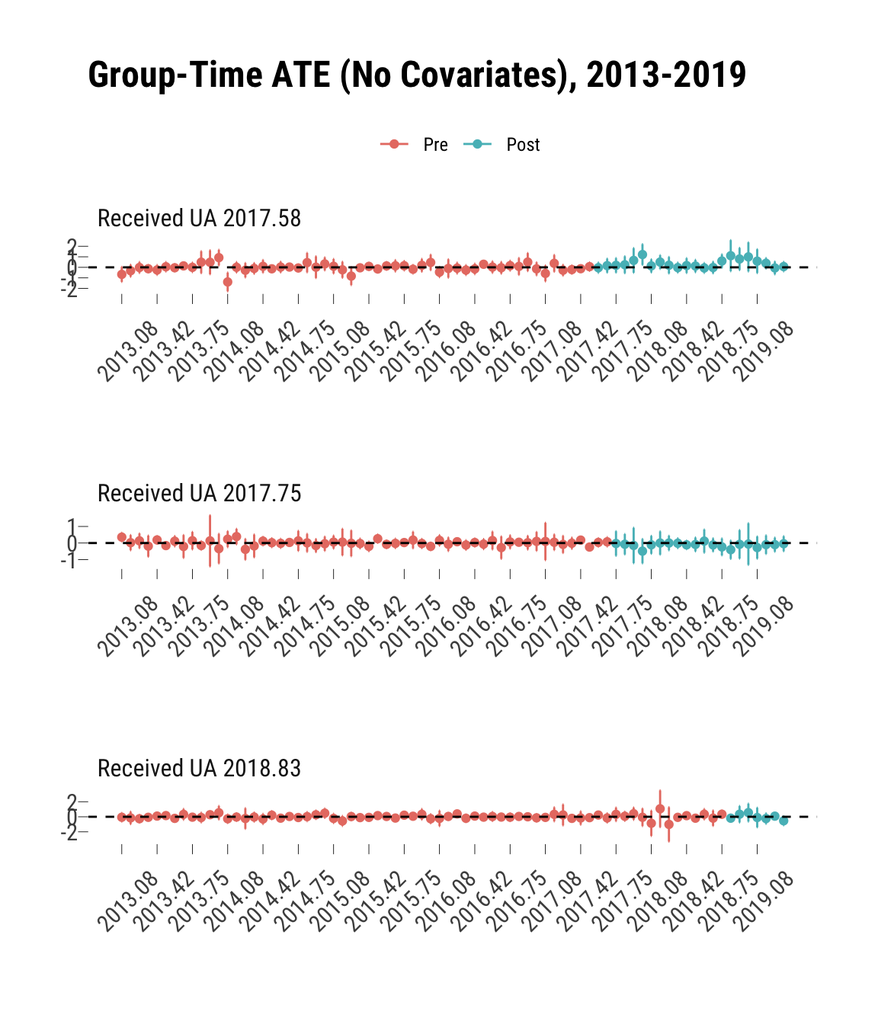

```r
ggdid(est_test,
      title = "Group-Time ATE (No Covariates), 2013-2019",
      grtitle = "Received UA",
      xgap = 12,
      theming = FALSE) +
  theme_ipsum_rc(grid = FALSE, ticks = TRUE) +
  theme(legend.position = "top",
        axis.text.x = element_text(angle = 45,
                                   margin = margin(t = 20)))
```

#### Dynamic Event Study w/ Plot (No Covariates)

This aggregates the group-time ATEs

```r
event_study <- aggte(est_test, type = "dynamic")

summary(event_study)
```

```
##
## Call:
## aggte(MP = est_test, type = "dynamic")
##
## Reference: Callaway, Brantly and Pedro H.C. Sant'Anna.  "Difference-in-Differences with Multiple Time Periods." Journal of Econometrics, Vol. 225, No. 2, pp. 200-230, 2021. <https://doi.org/10.1016/j.jeconom.2020.12.001>, <https://arxiv.org/abs/1803.09015>
##
##
## Overall summary of ATT's based on event-study/dynamic aggregation:
##     ATT    Std. Error     [ 95%  Conf. Int.]
##  0.1496        0.1289     -0.103      0.4022
##
##
## Dynamic Effects:
##  Event time Estimate Std. Error [95% Simult.  Conf. Band]
##       -5.75  -0.0636     0.2034       -0.6420      0.5149
##       -5.66  -0.1482     0.2991       -0.9988      0.7025
##       -5.58  -0.2591     0.1869       -0.7906      0.2724
##       -5.50  -0.0713     0.1227       -0.4203      0.2777
##       -5.41   0.0940     0.0916       -0.1666      0.3546
##       -5.33   0.1596     0.0818       -0.0731      0.3923
##       -5.25  -0.2120     0.1111       -0.5281      0.1040
##       -5.16   0.3191     0.2686       -0.4448      1.0831
##       -5.08  -0.0521     0.0904       -0.3093      0.2050
##       -5.00  -0.1006     0.2343       -0.7668      0.5657
##       -4.91   0.2763     0.1266       -0.0837      0.6362
##       -4.83   0.5346     0.3384       -0.4278      1.4971
##       -4.75  -0.2648     0.2137       -0.8726      0.3429
##       -4.67   0.3562     0.1001        0.0715      0.6410 *
##       -4.66  -0.0357     0.1523       -0.4688      0.3974
##       -4.58  -0.1036     0.2965       -0.9467      0.7395
##       -4.50  -0.3089     0.1775       -0.8136      0.1958
##       -4.42  -0.1867     0.2201       -0.8127      0.4393
##       -4.41  -0.3126     0.1514       -0.7431      0.1180
##       -4.33   0.0918     0.1075       -0.2138      0.3974
##       -4.25  -0.1507     0.0669       -0.3408      0.0395
##       -4.17   0.1089     0.1041       -0.1870      0.4049
##       -4.16  -0.1526     0.1114       -0.4695      0.1643
##       -4.08  -0.0487     0.0946       -0.3179      0.2205
##       -4.00   0.0203     0.0865       -0.2257      0.2663
##       -3.92  -0.1483     0.1056       -0.4485      0.1519
```

[output cut: 81 more lines]

```
##        1.17   0.3745     0.2147       -0.2363      0.9852
##        1.25   0.7157     0.3815       -0.3694      1.8008
##        1.33  -0.2745     0.2324       -0.9354      0.3864
##        1.34   0.7924     0.3795       -0.2871      1.8718
##        1.42   0.6286     0.3696       -0.4225      1.6798
##        1.50   0.3587     0.2900       -0.4662      1.1836
##        1.58  -0.0407     0.1341       -0.4220      0.3406
##        1.59   0.3824     0.1766       -0.1198      0.8846
##        1.67  -0.0583     0.2604       -0.7988      0.6822
##        1.75   0.0707     0.1688       -0.4095      0.5509
## ---
## Signif. codes: `*' confidence band does not cover 0
##
## Control Group:  Not Yet Treated,  Anticipation Periods:  0
## Estimation Method:  Doubly Robust
```

Dynamic Event Study Plot (No Covariates)

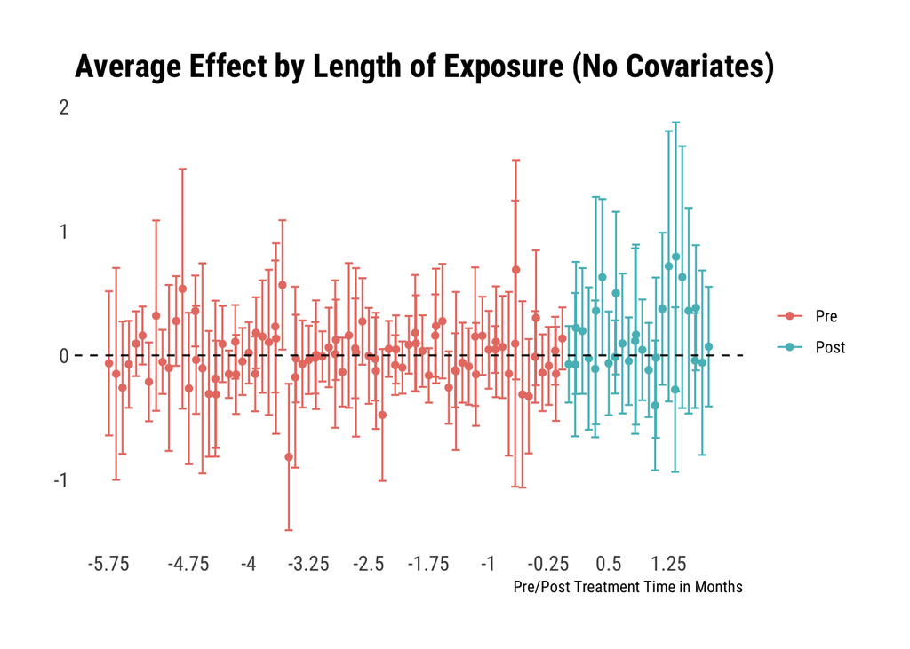

```r
ggdid(event_study,
      title = "Average Effect by Length of Exposure (No Covariates)",
      xlab = "Pre/Post Treatment Time in Months",
      xgap = 12,
      theming = FALSE) +
  theme_ipsum_rc(grid = F)
```

#### Overall Group Effects of Participating in Treatment (No Covariates)

```r
group_effects <- aggte(est_test, type = "group")
summary(group_effects)
```

```
##
## Call:
## aggte(MP = est_test, type = "group")
##
## Reference: Callaway, Brantly and Pedro H.C. Sant'Anna.  "Difference-in-Differences with Multiple Time Periods." Journal of Econometrics, Vol. 225, No. 2, pp. 200-230, 2021. <https://doi.org/10.1016/j.jeconom.2020.12.001>, <https://arxiv.org/abs/1803.09015>
##
##
## Overall summary of ATT's based on group/cohort aggregation:
##     ATT    Std. Error     [ 95%  Conf. Int.]
##  0.1482        0.1295    -0.1057      0.4021
##
##
## Group Effects:
##    Group Estimate Std. Error [95% Pointwise  Conf. Band]
##  2017.58   0.3602     0.2116         -0.0547      0.7750
##  2017.75  -0.1168     0.1762         -0.4622      0.2285
##  2018.83  -0.0106     0.2212         -0.4442      0.4230
## ---
## Signif. codes: `*' confidence band does not cover 0
##
## Control Group:  Not Yet Treated,  Anticipation Periods:  0
## Estimation Method:  Doubly Robust
```

Overall Group Effects Plot (No Covariates)

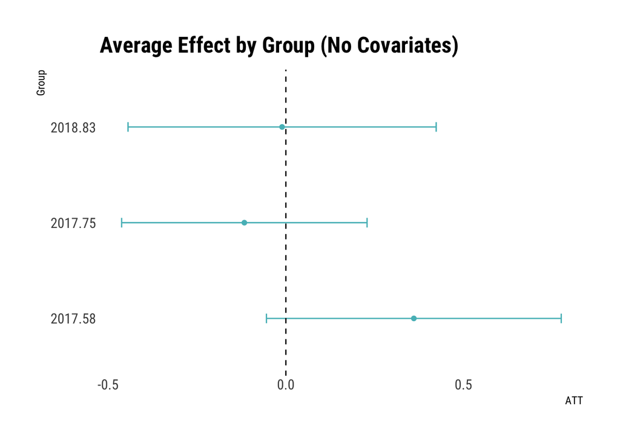

```r
ggdid(group_effects,
      title = "Average Effect by Group (No Covariates)",
      theming = FALSE) +
  theme_ipsum_rc(grid = F) +
  theme(legend.position = "none")
```

### CS-DiD: WITH covariates

```r
est_w_covars <- att_gt(yname = "n_violations_per_1k_units",
                       gname = "treat_yr_mo_num",
                       idname = "zip",
                       tname = "inspection_yr_mo_num",
                       xformla = ~ evict_rate_17 + rs_rate_17 + pct_pov_17,
                       data = violations_13_19,
                       control_group = "notyettreated",
                       allow_unbalanced_panel = TRUE,
                       est_method = "dr")
summary(est_w_covars)
```

```
##
## Call:
## att_gt(yname = "n_violations_per_1k_units", tname = "inspection_yr_mo_num",
##     idname = "zip", gname = "treat_yr_mo_num", xformla = ~evict_rate_17 +
##         rs_rate_17 + pct_pov_17, data = violations_13_19, allow_unbalanced_panel = TRUE,
##     control_group = "notyettreated", est_method = "dr")
##
## Reference: Callaway, Brantly and Pedro H.C. Sant'Anna.  "Difference-in-Differences with Multiple Time Periods." Journal of Econometrics, Vol. 225, No. 2, pp. 200-230, 2021. <https://doi.org/10.1016/j.jeconom.2020.12.001>, <https://arxiv.org/abs/1803.09015>
##
## Group-Time Average Treatment Effects:
##    Group    Time ATT(g,t) Std. Error [95% Simult.  Conf. Band]
##  2017.58 2013.08  -0.4397     0.2393       -1.1378      0.2583
##  2017.58 2013.17  -0.1664     0.2270       -0.8285      0.4958
##  2017.58 2013.25   0.2507     0.2219       -0.3966      0.8980
##  2017.58 2013.33  -0.1322     0.1369       -0.5315      0.2672
##  2017.58 2013.42  -0.1615     0.1817       -0.6915      0.3685
##  2017.58 2013.50   0.0040     0.1567       -0.4531      0.4612
##  2017.58 2013.58  -0.0312     0.1055       -0.3390      0.2765
##  2017.58 2013.67   0.1640     0.0977       -0.1211      0.4491
##  2017.58 2013.75  -0.1676     0.1930       -0.7305      0.3953
##  2017.58 2013.83   0.3259     0.2936       -0.5304      1.1822
##  2017.58 2013.92   0.4003     0.3150       -0.5185      1.3190
##  2017.58 2014.00   0.3053     0.3764       -0.7926      1.4032
##  2017.58 2014.08  -0.9452     0.3751       -2.0394      0.1490
##  2017.58 2014.17   0.1665     0.1929       -0.3961      0.7291
##  2017.58 2014.25   0.0681     0.2827       -0.7565      0.8927
##  2017.58 2014.33  -0.0783     0.1768       -0.5939      0.4372
##  2017.58 2014.42   0.1115     0.2128       -0.5091      0.7321
##  2017.58 2014.50  -0.1388     0.1217       -0.4939      0.2162
##  2017.58 2014.58   0.0602     0.1879       -0.4879      0.6083
##  2017.58 2014.67  -0.0407     0.0942       -0.3156      0.2342
##  2017.58 2014.75  -0.1145     0.1193       -0.4626      0.2336
##  2017.58 2014.83   0.1654     0.3103       -0.7397      1.0706
##  2017.58 2014.92   0.0351     0.3905       -1.1039      1.1742
##  2017.58 2015.00   0.1767     0.2474       -0.5451      0.8985
##  2017.58 2015.08  -0.0440     0.2416       -0.7487      0.6607
##  2017.58 2015.17   0.2208     0.3380       -0.7650      1.2067
##  2017.58 2015.25  -0.6733     0.2844       -1.5029      0.1564
##  2017.58 2015.33   0.0062     0.1298       -0.3723      0.3848
##  2017.58 2015.42   0.1199     0.1315       -0.2638      0.5036
```

[output cut: 189 more lines]

```
##  2018.83 2018.58   0.3593     0.2812       -0.4609      1.1795
##  2018.83 2018.67  -0.2016     0.4284       -1.4512      1.0480
##  2018.83 2018.75   0.2672     0.1717       -0.2337      0.7682
##  2018.83 2018.83  -0.2268     0.1792       -0.7494      0.2958
##  2018.83 2018.92   0.3195     0.4691       -1.0488      1.6878
##  2018.83 2019.00   0.4675     0.4671       -0.8949      1.8299
##  2018.83 2019.08  -0.2349     0.3414       -1.2306      0.7607
##  2018.83 2019.17  -0.1757     0.2283       -0.8415      0.4901
##  2018.83 2019.25   0.0771     0.1865       -0.4669      0.6210
##  2018.83 2019.33  -0.4915     0.2320       -1.1682      0.1853
## ---
## Signif. codes: `*' confidence band does not cover 0
##
## Control Group:  Not Yet Treated,  Anticipation Periods:  0
## Estimation Method:  Doubly Robust
```

*228 rows*

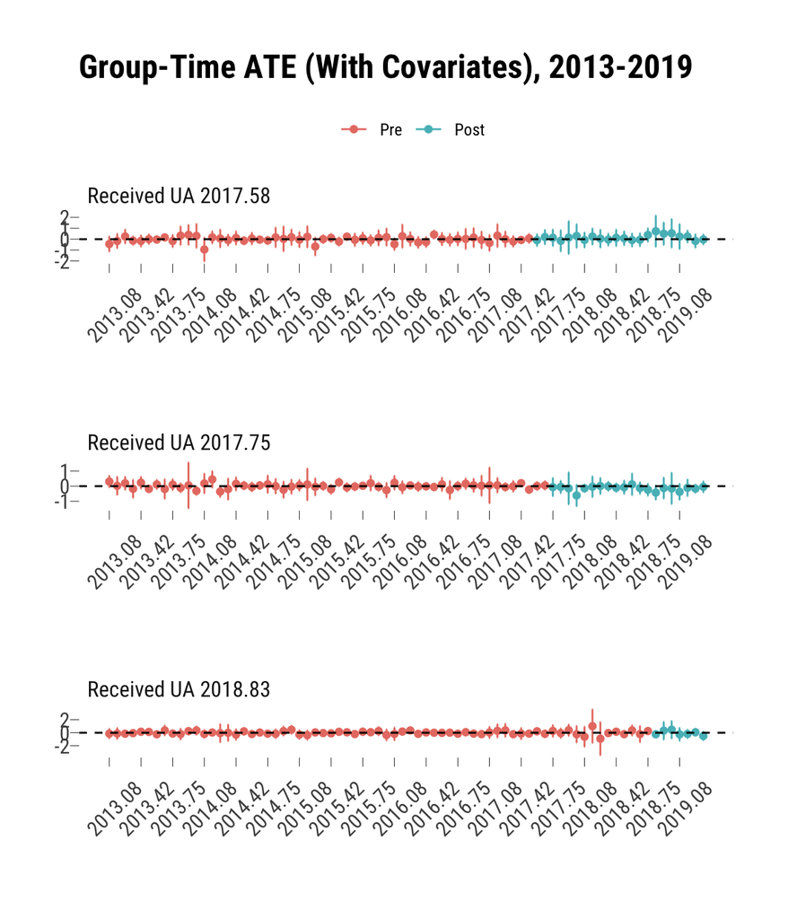

```r
ggdid(est_w_covars,
      title = "Group-Time ATE (With Covariates), 2013-2019",
      grtitle = "Received UA",
      xgap = 12,
      theming = FALSE) +
  theme_ipsum_rc(grid = FALSE, ticks = TRUE) +
  theme(legend.position = "top",
        axis.text.x = element_text(angle = 45,
                                   margin = margin(t = 20)))
```

```r
group_effects <- aggte(est_w_covars, type = "dynamic")
summary(group_effects)
```

```
##
## Call:
## aggte(MP = est_w_covars, type = "dynamic")
##
## Reference: Callaway, Brantly and Pedro H.C. Sant'Anna.  "Difference-in-Differences with Multiple Time Periods." Journal of Econometrics, Vol. 225, No. 2, pp. 200-230, 2021. <https://doi.org/10.1016/j.jeconom.2020.12.001>, <https://arxiv.org/abs/1803.09015>
##
##
## Overall summary of ATT's based on event-study/dynamic aggregation:
##     ATT    Std. Error     [ 95%  Conf. Int.]
##  0.0313        0.1176    -0.1992      0.2618
##
##
## Dynamic Effects:
##  Event time Estimate Std. Error [95% Simult.  Conf. Band]
##       -5.75  -0.1310     0.2451       -0.8528      0.5909
##       -5.66  -0.1145     0.2814       -0.9431      0.7141
##       -5.58  -0.1382     0.1696       -0.6377      0.3613
##       -5.50  -0.0554     0.1238       -0.4200      0.3091
##       -5.41   0.1542     0.1042       -0.1526      0.4610
##       -5.33   0.1316     0.0754       -0.0904      0.3535
##       -5.25  -0.2291     0.1222       -0.5890      0.1308
##       -5.16   0.3578     0.2610       -0.4108      1.1263
##       -5.08  -0.1188     0.0917       -0.3888      0.1513
##       -5.00  -0.2034     0.3417       -1.2097      0.8029
##       -4.91   0.2471     0.1659       -0.2414      0.7356
##       -4.83   0.3500     0.2181       -0.2922      0.9922
##       -4.75  -0.1828     0.2082       -0.7958      0.4302
##       -4.67   0.3054     0.1440       -0.1188      0.7296
##       -4.66   0.0386     0.1461       -0.3918      0.4689
##       -4.58  -0.0186     0.2436       -0.7360      0.6988
##       -4.50  -0.1745     0.1821       -0.7107      0.3617
##       -4.42  -0.1764     0.1936       -0.7464      0.3937
##       -4.41  -0.2004     0.1643       -0.6844      0.2835
##       -4.33   0.2384     0.1168       -0.1055      0.5822
##       -4.25  -0.1587     0.0770       -0.3853      0.0680
##       -4.17   0.1140     0.1103       -0.2107      0.4387
##       -4.16  -0.0959     0.1222       -0.4557      0.2638
##       -4.08  -0.0796     0.0991       -0.3715      0.2123
##       -4.00  -0.0287     0.0893       -0.2915      0.2342
##       -3.92  -0.1101     0.1118       -0.4392      0.2191
```

[output cut: 81 more lines]

```
##        1.17   0.2150     0.1734       -0.2957      0.7256
##        1.25   0.4377     0.3761       -0.6698      1.5452
##        1.33  -0.3770     0.1977       -0.9593      0.2053
##        1.34   0.5061     0.3536       -0.5352      1.5475
##        1.42   0.3263     0.3303       -0.6463      1.2989
##        1.50   0.1072     0.2696       -0.6867      0.9011
##        1.58  -0.0442     0.1290       -0.4242      0.3359
##        1.59   0.2487     0.1995       -0.3387      0.8360
##        1.67  -0.1616     0.2204       -0.8108      0.4875
##        1.75  -0.0210     0.1622       -0.4985      0.4565
## ---
## Signif. codes: `*' confidence band does not cover 0
##
## Control Group:  Not Yet Treated,  Anticipation Periods:  0
## Estimation Method:  Doubly Robust
```

*117 rows*

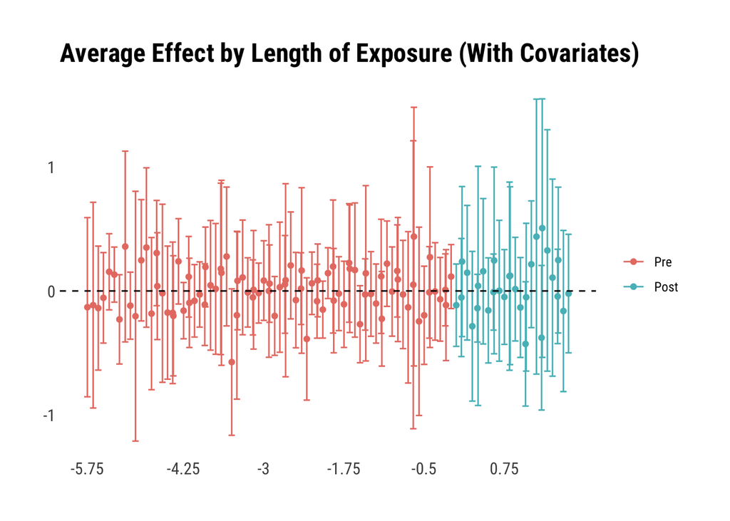

```r
ggdid(group_effects,
      title = "Average Effect by Length of Exposure (With Covariates)",
      xgap = 20,
      theming = FALSE) +
    theme_ipsum_rc(grid = FALSE)
```

```r
group_effects <- aggte(est_w_covars, type = "group")
summary(group_effects)
```

```
##
## Call:
## aggte(MP = est_w_covars, type = "group")
##
## Reference: Callaway, Brantly and Pedro H.C. Sant'Anna.  "Difference-in-Differences with Multiple Time Periods." Journal of Econometrics, Vol. 225, No. 2, pp. 200-230, 2021. <https://doi.org/10.1016/j.jeconom.2020.12.001>, <https://arxiv.org/abs/1803.09015>
##
##
## Overall summary of ATT's based on group/cohort aggregation:
##     ATT    Std. Error     [ 95%  Conf. Int.]
##  0.0294        0.1193    -0.2044      0.2632
##
##
## Group Effects:
##    Group Estimate Std. Error [95% Pointwise  Conf. Band]
##  2017.58   0.1495     0.2042         -0.2507      0.5496
##  2017.75  -0.1435     0.1355         -0.4090      0.1221
##  2018.83  -0.0378     0.2549         -0.5374      0.4617
## ---
## Signif. codes: `*' confidence band does not cover 0
##
## Control Group:  Not Yet Treated,  Anticipation Periods:  0
## Estimation Method:  Doubly Robust
```

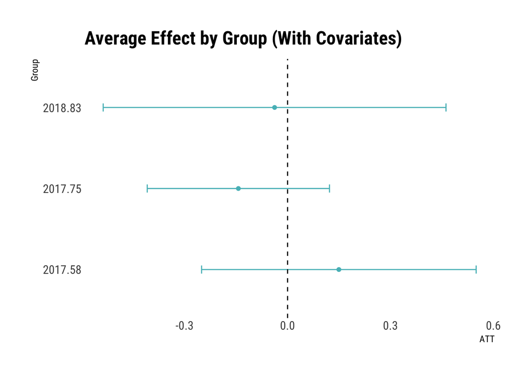

```r
ggdid(group_effects,
      title = "Average Effect by Group (With Covariates)",
      theming = FALSE) +
  theme_ipsum_rc(grid = F) +
  theme(legend.position = "none")
```

### Parallel Trends Test

via [Callaway’s documentation](https://cran.r-project.org/web/packages/did/vignettes/pre-testing.html): “The did package contains an additional pre-test for the conditional parallel trends assumption in the conditional_did_pretest function.”

```r
cdp_wo_covars <- conditional_did_pretest(yname = "n_violations_per_1k_units",
                               tname = "inspection_yr_mo_num",
                               idname = "zip",
                               gname = "treat_yr_mo_num",
                               control_group = "notyettreated",
                               xformla = ~1,   # equivalent to NULL
                               data = violations_13_19)
```

```
## Step 1 of 2: Computing test statistic....
## Step 2 of 2: Simulating limiting distribution of test statistic....
```

```r
summary(cdp_wo_covars)
```

```
## Reference: Callaway, Brantly and Pedro H.C. Sant'Anna.  "Difference-in-Differences with Multiple Time Periods." Journal of Econometrics, Vol. 225, No. 2, pp. 200-230, 2021. <https://doi.org/10.1016/j.jeconom.2020.12.001>, <https://arxiv.org/abs/1803.09015>
## Cramer von Mises:
##   Test Statistic:  2451.863
##   Critical Value:  1821.837
##   P-value       :  0
##
## Clustering on   :  ,
## X formula       :  ~ 1
```

```r
cdp_three_covars <- conditional_did_pretest(yname = "n_violations_per_1k_units",
                               tname = "inspection_yr_mo_num",
                               idname = "zip",
                               gname = "treat_yr_mo_num",
                               control_group = "notyettreated",
                               xformla = ~ evict_rate_17 + rs_rate_17 + pct_pov_17,
                               data = violations_13_19)
```

```
## Step 1 of 2: Computing test statistic....
## Step 2 of 2: Simulating limiting distribution of test statistic....
```

```r
summary(cdp_three_covars)
```

```
## Reference: Callaway, Brantly and Pedro H.C. Sant'Anna.  "Difference-in-Differences with Multiple Time Periods." Journal of Econometrics, Vol. 225, No. 2, pp. 200-230, 2021. <https://doi.org/10.1016/j.jeconom.2020.12.001>, <https://arxiv.org/abs/1803.09015>
## Cramer von Mises:
##   Test Statistic:  123.0395
##   Critical Value:  121.8652
##   P-value       :  0.043
##
## Clustering on   :  ,
## X formula       :  ~ evict_rate_17 + rs_rate_17 + pct_pov_17
```

```r
cdp_four_covars <- conditional_did_pretest(yname = "n_violations_per_1k_units",
                               tname = "inspection_yr_mo_num",
                               idname = "zip",
                               gname = "treat_yr_mo_num",
                               control_group = "notyettreated",
                               xformla = ~ evict_rate_17 + rs_rate_17 + pct_pov_17 + pct_wh_17,
                               data = violations_13_19)
```

```
## Step 1 of 2: Computing test statistic....
## Step 2 of 2: Simulating limiting distribution of test statistic....
```

```r
summary(cdp_four_covars)
```

```
## Reference: Callaway, Brantly and Pedro H.C. Sant'Anna.  "Difference-in-Differences with Multiple Time Periods." Journal of Econometrics, Vol. 225, No. 2, pp. 200-230, 2021. <https://doi.org/10.1016/j.jeconom.2020.12.001>, <https://arxiv.org/abs/1803.09015>
## Cramer von Mises:
##   Test Statistic:  22.89101
##   Critical Value:  27.66883
##   P-value       :  0.34
##
## Clustering on   :  ,
## X formula       :  ~ evict_rate_17 + rs_rate_17 + pct_pov_17 + pct_wh_17
```

```r
cdp_three_table <- as.data.frame(do.call(cbind, cdp_three_covars)) %>%
  select(xformla, CvM, CvMcval, CvMpval) %>%
  distinct() %>%
  slice(2)

cdp_four_table <- as.data.frame(do.call(cbind, cdp_four_covars)) %>%
  select(xformla, CvM, CvMcval, CvMpval) %>%
  distinct() %>%
  slice(2)

cdp_table <- as.data.frame(do.call(cbind, cdp_wo_covars)) %>%
  select(xformla, CvM, CvMcval, CvMpval) %>%
  distinct() %>%
  slice(2) %>%
  bind_rows(cdp_three_table, cdp_four_table) %>%
  mutate(xformla = str_replace(xformla, "1\\b", "without covariates"))
cdp_table %>%
  kable(
    digits = 2,
    caption = 'Cramer von Mises Test of Conditional Parallel Trends Assumption',
    col.names = c('Covariates', 'Test Statistic', 'Critical Value', 'P-Value')) %>%
    kable_styling(full_width = F, html_font = "Roboto Condensed")
```

Cramer von Mises Test of Conditional Parallel Trends Assumption

| Covariates | Test Statistic | Critical Value | P-Value |
| --- | --- | --- | --- |
| without covariates | 2451.863 | 1821.837 | 0 |
| evict_rate_17 + rs_rate_17 + pct_pov_17 | 123.0395 | 121.8652 | 0.043 |
| evict_rate_17 + rs_rate_17 + pct_pov_17 + pct_wh_17 | 22.89101 | 27.66883 | 0.34 |